# Data Visualization and Communication Lab6: ggplot2 Part 2

Jennifer Sunwoo Ha

March 9th, 2018

### Exercise 2.1

Load the “gapminder” dataset contained in the package “gapminder”. Using what we learned last week, in addition to the information just given above, create an attractive,well-labeled ggplot to help visualize how life expectancy varies across continents (hint: scatterplots won’t save you now!)

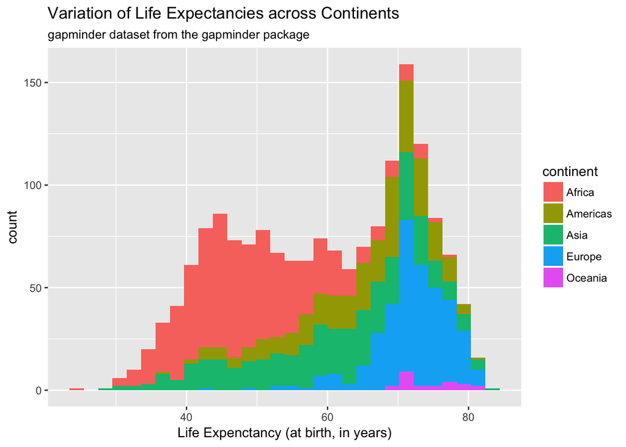

```r
plot <- ggplot(gapminder, aes(x = lifeExp, fill = continent)) + geom_bar(stat = "bin") + labs(title="Variation of Life Expectancies across Continents", subtitle="gapminder dataset from the gapminder package", y="count", x="Life Expenctancy (at birth, in years)")
plot
```

### Exercise 2.2

Taking the plot you made in the previous assignment (#2.1) as your base, make at least three aesthetic adjustments using the techniques described above.

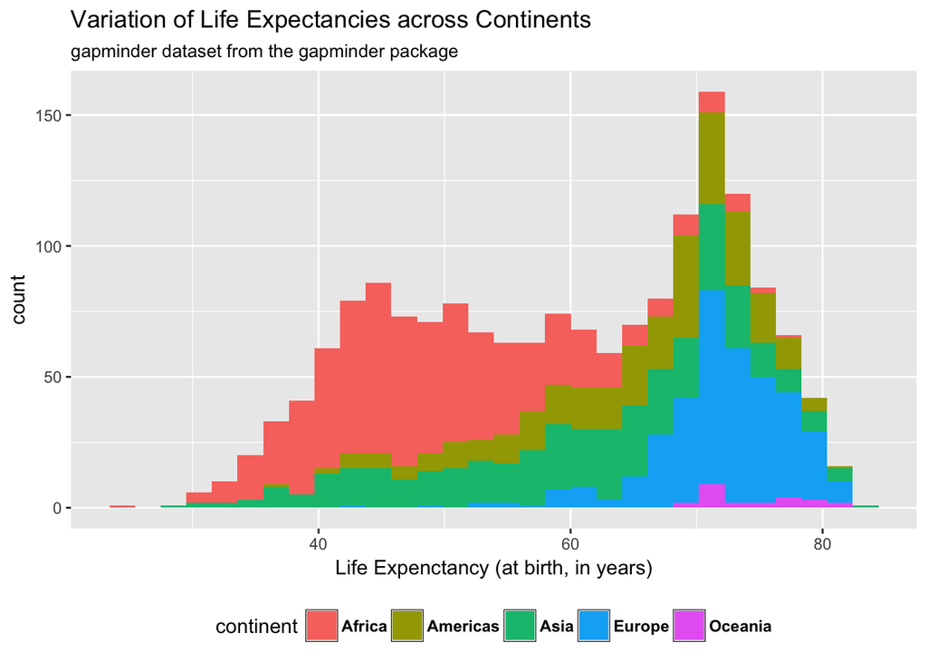

```r
plot + theme(legend.key = element_rect(colour = "black", size = 0.2), legend.position = "bottom", legend.text = element_text(face= "bold"))
```

### Exercise 2.3.1

Using this week’s lesson on time series in R, convert the plot you made and labeled in assignments 2.1 and 2.2 into a time series plot that displays changes in life expectancy over time, grouping your observations by continent.

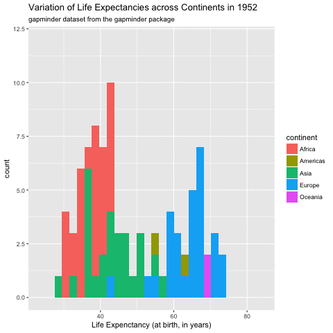

```r
gapminder <-
  gapminder %>%
  mutate(year = as.factor(year))

animation <- ggplot(gapminder, aes(x = lifeExp, fill = continent, frame = year)) + geom_bar(stat = "bin", position = "identity") + labs(title="Variation of Life Expectancies across Continents in", subtitle="gapminder dataset from the gapminder package", y="count", x="Life Expenctancy (at birth, in years)")

gganimate(animation, "/Users/jenniferha/Documents/New College/3rd Year/Spring 2018/Data Visualization/DataVis2018/Lab6/plot1.gif")
```

### Exercise 2.3.2

Now demonstrate how much more information we can display with gganimate, using this package to analyze how the relationship between GDP/Capita and Life Expectancy changes over time, grouping our observations by both continent and population size. Your final animated output should include titles, axis labels, and legend text that are intuitive and that have been customized using at least some of the aesthetic options reviewed earlier in this lab.

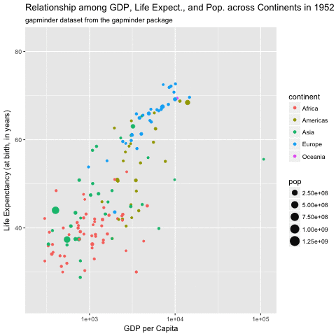

```r
animation2 <- ggplot(gapminder, aes(gdpPercap, lifeExp, size = pop, color = continent, frame = year)) + geom_point() + scale_x_log10() + labs(title="Relationship among GDP, Life Expect., and Pop. across Continents in", subtitle="gapminder dataset from the gapminder package", y="Life Expenctancy (at birth, in years)", x="GDP per Capita")

gganimate(animation2, "/Users/jenniferha/Documents/New College/3rd Year/Spring 2018/Data Visualization/DataVis2018/Lab6/plot2.gif")
```